# Proceso de ajuste del modelo TAR para la estimación del efecto *Pass through*

El presente apartado sirve tiene como finalidad detallar el proceso de ajuste del modelo TAR utilizado para la estimación del efecto pass-through del tipo de cambio para Guatemala por lo que se omite la explicación del modelo en cuestión y se concentra únicamente en el código y proceso de estimación.

El punto de partida para el ajuste del modelo TAR es conocer los umbrales que separan cada uno de los regímenes inflacionarios. Debido al hecho que estos se desconocen el primer paso consiste en la estimación de estos. El procedimiento a seguir será el propuesto por Chan(1993) el cual requiere de 3 pasos a seguir.

1. Se ordenan de menor a mayor las observaciones de la variable que define el estado del sistema y se procede a eliminar el 30% de las observaciones extremas[^1]. Este será el conjunto de umbrales posibles.
2. Se ajusta el modelo TAR teórico por cada uno de los umbrales y se captura de cada modelo la suma de residuos al cuadrado *SSR*.
3. Las *SSR* son función del umbral utilizado para el ajuste del modelo por lo que se grafican *SSR* contra umbrales obteniendo así la función *SSR*. Si uno de los umbrales dentro del conjunto es el verdadero umbral del modelo la *SSR* disminuirá en la meda en la cual se aproxima al umbral. Si hay más de un umbral la función *SSR* tendrá tantos mínimos como umbrales a considerar dentro del modelo.

Luego de estimados los umbrales se procede a justar el modelo TAR con los umbrales seleccionados.

# Modelo teórico inicial

El modelo teórico es una descomposición factorial de la inflación de la siguiente forma:

$$\Delta\%P_t = \beta_0 +
\beta_1\Delta\%P_{t-1} + \beta_2\Delta\%P_t^{EUA} +
\beta_3\%Y^gap + \beta_4\Delta\%e_t + I_t\delta\Delta\%e_t$$

donde:

$\Delta\%P_t$ Tasa de variación del Índice de Precios al Consumidor de Guatemala

$\beta_0$ Componente autónomo de la tas de inflación

$\Delta\%P_{t-1}$ Componente inercial de la inflación

$\Delta\%e_t$ Tasa de variación del tipo de cambio (tasa de depreciación del tipo de cambio)

$\Delta\%P_{t}^{EUA}$ Tasa de variación del Índice de Precios al Consumidor de Estados Unidos

$Y_t^{brecha}$ Brecha relativa del producto respecto del potencial

El modelo considera a la infalción inercial ($\Delta\%P_{t-1}$) como la variable que define el estado del sistema, además de ello el uso de la variable dummy orgina dos tipos de regímenes uno de inflación ‘baja’ y otro de inflación ‘alta’.

## Datos utilizados para ajsutar el modelo

Todos los datos se obtuvieron de fuentes oficiales como el [Banco de guatemala](https://www.banguat.gob.gt/) y [U.S. Bureu of Labor Statics](https://www.bls.gov/). Además se adjunta la [base de datos](https://github.com/jorgeorenos/Pass-through/blob/cambios/Datos%20utilizados%20para%20el%20modelo.csv) utilizada para ajustar el modelo[^2].

Conjunto de datos utilizados

| Inflación intermensual de Guatemala | Componente inercial | Inflación intermensual de Estados Unidos | Brecha del producto | Dpreciación del tipo de cambio |
| --- | --- | --- | --- | --- |
| 0.73 | 1.37 | 0.39977 | 0.53268 | -0.84933 |
| 0.54 | 0.73 | 0.22753 | -1.89777 | -0.49274 |
| 0.43 | 0.54 | 0.39728 | 1.49072 | 0.65881 |
| 0.30 | 0.43 | 0.45223 | -0.78380 | 0.26956 |
| 0.73 | 0.30 | 0.16882 | -1.90104 | 0.37824 |
| 0.87 | 0.73 | -0.28090 | -1.36618 | 0.00026 |

# Estimación de los umbrales de inflación

A continuación, se presenta el código con el cual se creó el conjunto de umbrales posibles así como el ajuste del modelo TAR especificado anteriormente por cada umbral posible. El número total de modelos estimados fue de 180.

```r
# Creación de todos los posibles umbrales
# Número de umbrales fuera por debajo o arriba de la muestra

umbrales_fuera <- length(inercial) - round(dim(datos)[1] - dim(datos)[1]*0.3, digits = 0)

# posibles umbrales del modelo
# inercial es un vector que contiene el rezago de la inflación, variable que define el estado del sistema

posibles <- sort(inercial)
posibles <- posibles[round((umbrales_fuera/2 + 1), 0):
                       (length(inercial)-round(umbrales_fuera/2,0))]

# Finalmente posibles es el vector que contiene el conjunto de umbrales posibles utilizados para estimar el modelo

# Estimación de los 180 modelos

nombre_modelos <- c()
modelos <- list()
bases <- list()

# Ciclo para estimar y nombrar los modelos

for (i in c(1:length(posibles))) {

  # Se genera un nombre para cada modelo a fin de poder tener una correcta identificación

  nombre_modelos[i] <- c(sprintf("modelo_%s_%s", i, posibles[i]))

  # Se genera una base de datos para cada modelo
  # en esta base de datos d es la variable dummy que separa los regímenes inflacionarios

  m <- mutate(datos_modelo,
                     d = ifelse(inercial<posibles[i], yes = 0, no = 1))

  # Bases es la lista que almacena las bases de datos utilizadas
  # Aunque era posible estimar los modelos sin almacenar las bases de datos se almacenaron
  # para tener una ferencia de ellas

  bases[[i]] <- m

  modelo <- lm(bases[[i]],
                      formula = inf_gt_intermensual ~ 1 +
                        deprec*d + inercial +
                        inf_eua_intermensual + var_brecha - d)

  modelos[[i]] <- modelo

}

# Se coloca el nombre a cada base de datos y modelo

names(modelos) <- nombre_modelos
names(bases) <- nombre_modelos
```

Luego de la estimación de los modelos se procede al cálculo de la *SSR* de cada modelo.

```r
# SSR es el vector que contiene la suma de residuos al cuadrado de cada modelo

ssr <- c()

for (i in c(1:length(posibles))) {

  ssr[i] <- sum(modelos[[i]]$residuals^2)

}
```

### Identificación de los umbrales a partir de la función SSR

Una vez determinada la ssr se procede a la identificación de los umbrales escogiendo aquellos que minimicen la ssr en cada modelo. Dado que R no cuenta con una función nativa para la identificación de más de un mínimo se programó una función llamada *minimos* y que se deja [aquí](https://github.com/jorgeorenos/Pass-through/blob/cambios/C%C3%B3digo/minimos.R) en dado caso el lector quiera revisarla.

```r
# Cargando la función mínimos

source("minimos.R")

# Una vez se tiene la función se procede a deterinar cuales son los umbrales del modelo

umbrales <- posibles[ssr %in% minimos(ssr, 4)]

names(modelos[ssr %in% minimos(ssr, 4)])
```

```
## [1] "modelo_18_0.14"  "modelo_19_0.14"  "modelo_95_0.44"  "modelo_96_0.44"
## [5] "modelo_97_0.44"  "modelo_135_0.56" "modelo_176_0.83" "modelo_177_0.83"
```

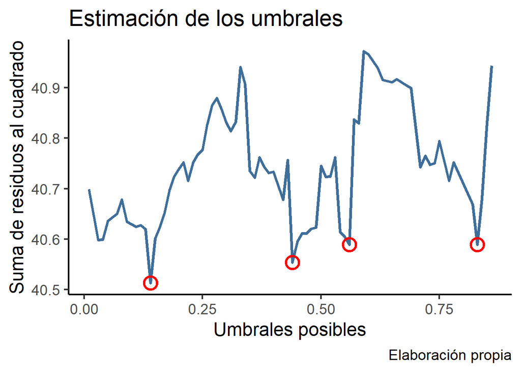

```r
# Como se observa los umbrales de inflación que minizan los errores son
# 0.14, 0.44, 0.56 y 0.83% de infalción intermensual.

# De forma gráfica se tiene la función SSR y la identificación de los mínimos

ggplot() +
  geom_line(aes(y = ssr, x = posibles), colour = "#3F6E9A", size = 1.3) +
  labs(title = "Estimación de los umbrales",
       y = "Suma de residuos al cuadrado", x = "Umbrales posibles",
       caption = "Elaboración propia") +

  geom_point(aes(x = umbrales,
                 y = ssr[ssr %in% minimos(ssr, 4)]), shape = 1, colour = "red",
             size = 5, stroke = 1.7) +

  theme_classic(base_size = 18)
```

# Estiamción del modelo con dos umbrales, tres regímenes

y el modelo quedó especificado la siguiente forma:

$$\Delta\%P_t = \beta_0 +
\beta_1\Delta\%P_{t-1} + \beta_2\Delta\%P_t^{EUA} +
\beta_3\%Y^gap + \beta_4\Delta\%e_t + I_t^1\delta_1\Delta\%e_t +
I_t^2\delta_2\Delta\%e_t$$

Donde:

$I_t^1$ Variable dummy que es 1 en el régimen de inflación baja

$I_t^2$ Variable dummy que es 1 en el régimen de inflación media

Dejando como escenario base del ajuste del modelo TAR al régimen de inflación alta.

El código para el ajuste del modelo es el siguiente:

```r
# Datos_TAR es la base de datos con la que se estimó el modelo especificado anteriormente

datos_TAR <- datos_modelo %>%
                mutate(dmen = ifelse(inercial < 0.14, yes = 1, no = 0),
                       dentre = ifelse(inercial>= 0.14 & inercial<= 0.83,
                                       yes = 1, no = 0))

attach(datos_TAR)
TAR <- lm(datos_TAR, formula = inf_gt_intermensual ~ 1 +
            deprec*dmen + deprec*dentre +
            inercial + inf_eua_intermensual + var_brecha - dmen - dentre)

detach(datos_TAR)
```

Con los que se obtuvieron los siguientes resultados:

Coeficientes

|  | Estimate | Std. Error | t value | Pr(>\|t\|) |
| --- | --- | --- | --- | --- |
| $\beta_0$ | 0.2536201 | 0.0386360 | 6.5643489 | 0.0000000 |
| $\beta_4$ | 0.1040490 | 0.0831249 | 1.2517189 | 0.2118469 |
| $\beta_1$ | 0.3244242 | 0.0612748 | 5.2945742 | 0.0000003 |
| $\beta_2$ | 0.2388209 | 0.0657822 | 3.6304785 | 0.0003434 |
| $\beta_3$ | -0.0244780 | 0.0172573 | -1.4184138 | 0.1573204 |
| $\delta_1$ | -0.2493846 | 0.1267410 | -1.9676706 | 0.0502158 |
| $\delta_2$ | -0.0939505 | 0.0959698 | -0.9789588 | 0.3285505 |

# Estimación del efecto pass-through

finalmente la estimación del efecto está dada por las interacciones que propician las variables dummy.

[output not shown]

## Comprobación de los supuestos

En este apartado se hace una comprobación de los supuestos de MCO para el modelo ajustado.

### Normalidad

```r
tseries::jarque.bera.test(TAR$residuals)
```

```
##
##  Jarque Bera Test
##
## data:  TAR$residuals
## X-squared = 10.264, df = 2, p-value = 0.005906
```

```r
shapiro.test(TAR$residuals)
```

```
##
##  Shapiro-Wilk normality test
##
## data:  TAR$residuals
## W = 0.98592, p-value = 0.01278
```

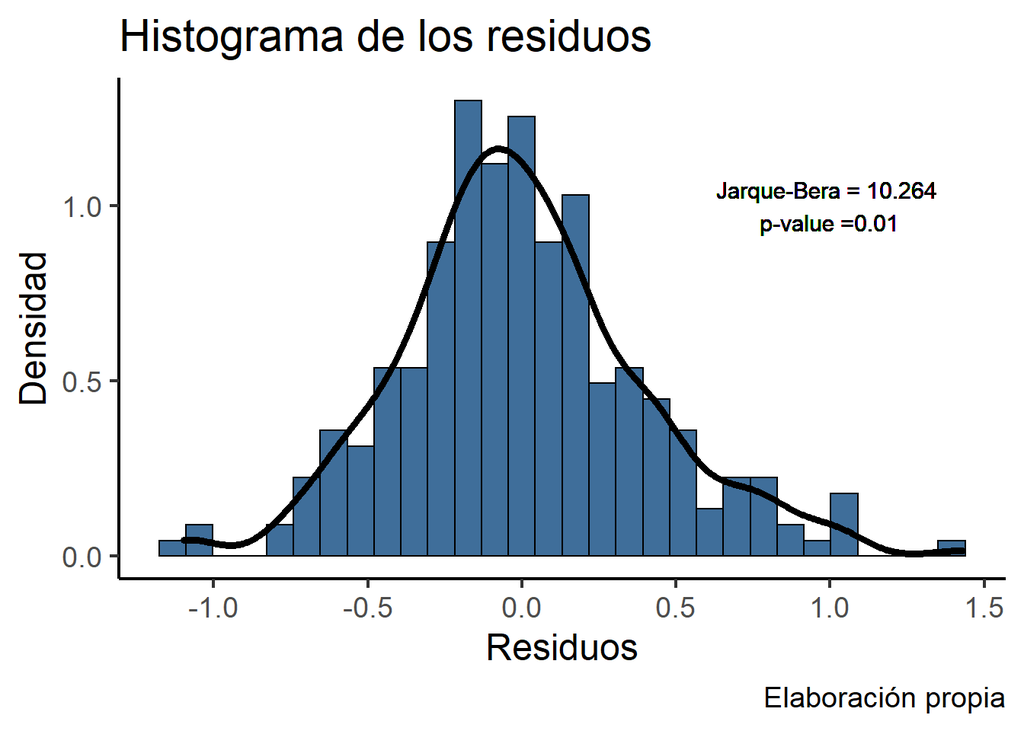

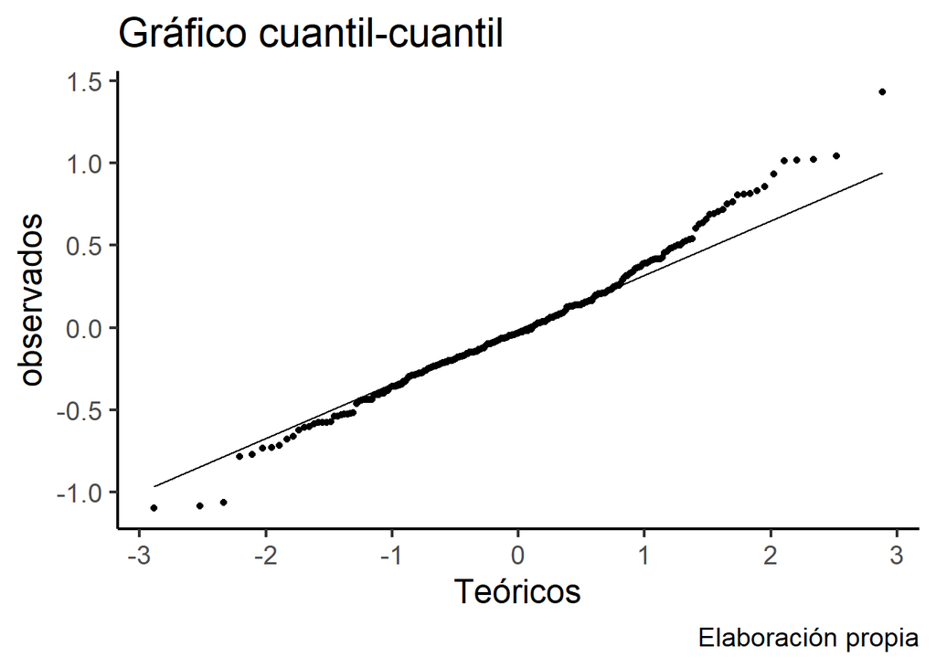

### Autocorrelación

La pruba de Breusch-Godfrey muestra que no hay autocorrelación de los errores.

```r
lmtest::bgtest(TAR)
```

```
##
##  Breusch-Godfrey test for serial correlation of order up to 1
##
## data:  TAR
## LM test = 1.19, df = 1, p-value = 0.2753
```

### Heterocedasticidad

La prueba Breusch-Pagan de heterocedasticidad muestran una varianza homocedastica.

```r
lmtest::bptest(TAR)
```

```
##
##  studentized Breusch-Pagan test
##
## data:  TAR
## BP = 6.5717, df = 6, p-value = 0.3623
```

### Multicolinealidad

Todos los factores de inflación de la varianza son inferiores a 5 por lo que el modelo no sufre de problemas de multicolinealidad.

```r
car::vif(TAR)
```

```
## there are higher-order terms (interactions) in this model
## consider setting type = 'predictor'; see ?vif
```

```
##               deprec             inercial inf_eua_intermensual
##             4.799170             1.157172             1.048518
##           var_brecha          deprec:dmen        deprec:dentre
##             1.022142             1.794247             3.926314
```

# Análsisi de variazas y covarianzas

Siguiendo la recomendación de Baqueiro, Díaz de Leon & Torres (2004) se calculan las covarianzas entre tipo de cambio y precios para cada uno de los regímens así como la varianza del tipo de cambio. La razón de ello es para determinar el motivo por el cual el coeficiente asociado al pass-through disminuye.

$$\beta_i =
\frac{cov_{x_iy}}{var_{x_i}}$$

Si la covarianza entre el tipo de cambio y los precios disminuye el coeficiente también lo hará algo que también sucede si aumenta la varianza del tipo de cambio.

| regimen | covarianza | varinza |
| --- | --- | --- |
| inflación alta | 0.0218614 | 0.6030626 |
| inflación baja | -0.0315643 | 0.3741780 |
| inflación media | -0.0028357 | 0.4230115 |

[^1]: Se elimina el 15% de las observaciones extremas superiores e inferiores.
[^2]: Para estimar la brecha del producto se utilizó el Indice Mensual de la Actividad Económica (IMAE), serie que fue desestacionalizada para posteriormente aplicarse el filtro Hodrick-Prescott. el trataiento de la serie lo puede econtrar en este aquí: [serie IMAE](https://jorgeorenos.github.io/serie-IMAE/)